# Tugas-Pertemuan-4

#### **2. Plot ACF, PACF, dan EACF**

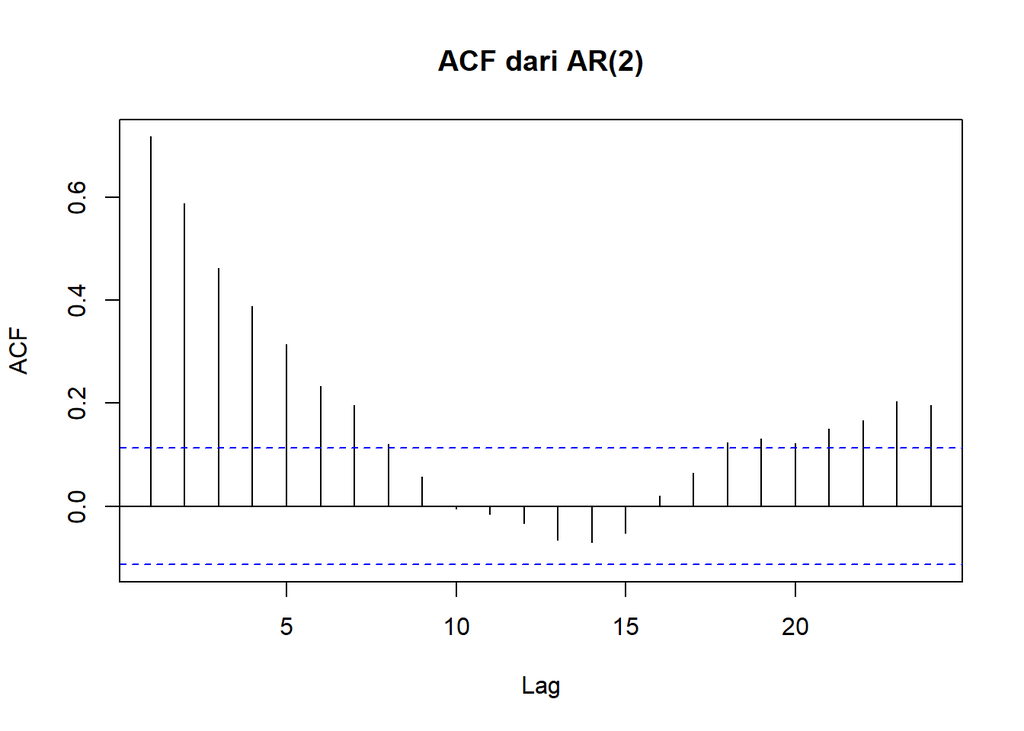

```r
acf(ar2_manual, main="ACF dari AR(2)")
```

Berdasarkan plot ACF tersebut terlihat bahwa plot ACF cenderung *tails off* dan cenderung membentuk pola grafik sinus

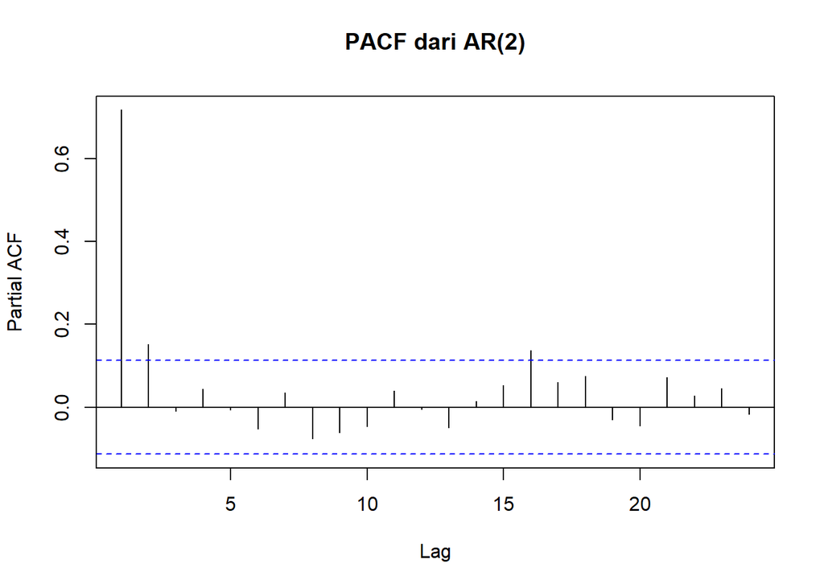

```r
pacf(ar2_manual, main="PACF dari AR(2)")
```

Berdasarkan plot PACF tersebut, terlihat bahwa plot PACF *cuts off* pada lag kedua, sejalan dengan teori yang ada

```r
eacf(ar2_manual)
```

```
## AR/MA
##   0 1 2 3 4 5 6 7 8 9 10 11 12 13
## 0 x x x x x x x x o o o  o  o  o
## 1 x o o o o o o o o o o  o  o  o
## 2 o o o o o o o o o o o  o  o  o
## 3 x x o o o o o o o o o  o  o  o
## 4 x x o o o o o o o o o  o  o  o
## 5 o x o x o o x o o o o  o  o  o
## 6 x x x x o o o o o o o  o  o  o
## 7 x x x o x x o o o o o  o  o  o
```

Berdasarkan pola segitiga nol pada plot EACF, terlihat bahwa segitiga nol berada pada ordo AR(2) dan ordo MA(0)

#### **3. *Scatterplot* Antar Lag**

##### **Korelasi antara** $Y_t$ **dengan** $Y_{t−1}$

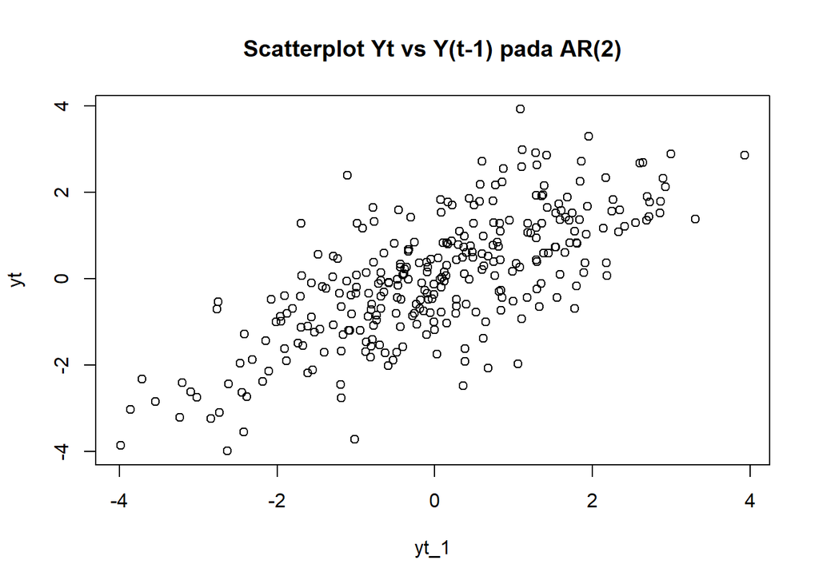

```r
# Yt
yt <- ar2_manual[-1]
# Yt-1
yt_1 <- ar2_manual[-n]

plot(y=yt, x=yt_1, main="Scatterplot Yt vs Y(t-1) pada AR(2)")
```

Scatterplot ini menggambarkan hubungan antara nilai deret waktu saat ini ($Y_t$) dengan nilai pada satu periode sebelumnya ($Y_{t-1}$) untuk sebuah proses **AR(2)**. Pola titik-titik yang membentuk awan lonjong dan menanjak dengan jelas dari kiri bawah ke kanan atas menunjukkan adanya **korelasi linear positif yang moderat hingga kuat**. Ini berarti nilai pada periode sebelumnya memiliki pengaruh yang cukup besar dan langsung terhadap nilai saat ini; jika nilai $Y_{t-1}$ tinggi, maka nilai $Y_t$ juga cenderung tinggi. Struktur linear yang jelas seperti ini adalah ciri khas dari proses Autoregressive (AR), yang menandakan adanya dependensi yang kuat pada nilai masa lalunya.

```r
cor(yt, yt_1)
```

```
## [1] 0.7181941
```

Nilai korelasi dari simulasi ini kita bandingkan dengan perhitungan teoritis (Persamaan Yule-Walker):

$$\rho_1 = \frac{\phi_1}{1 - \phi_2} = \frac{0.5}{1 - 0.2} =
\frac{0.5}{0.8} = 0.625$$